# Prospers Loan Data Analysis

## Investigation Overview

Prosper is a financial company that matches investors and borrowers in a financially and socially rewarding way.

The goal of this data analysis project is to understand the factors that are related to loan status

## Dataset Overview

There are 113,937 loans in the dataset with 81 features. Most variables are numeric and categorical in nature. The dataset features can be split into two main categories:

- Borrower information
- Loan performance information

The independent variables of interest are: ProsperScore,ListingCategory,EmploymentStatus,EmploymentStatusDuration,IsBorrowerHomeowner,CurrentCreditLines, OpenRevolvingAccounts,DebtToIncomeRatio,IncomeVerifiable,LoanOriginalAmount`

## Loan Status Distribution

About 95,000 or 83% of all Prosper loans are current or completed. However, Prosper had approximately 17,000 or 15% of its loans defaulted or charged-off.

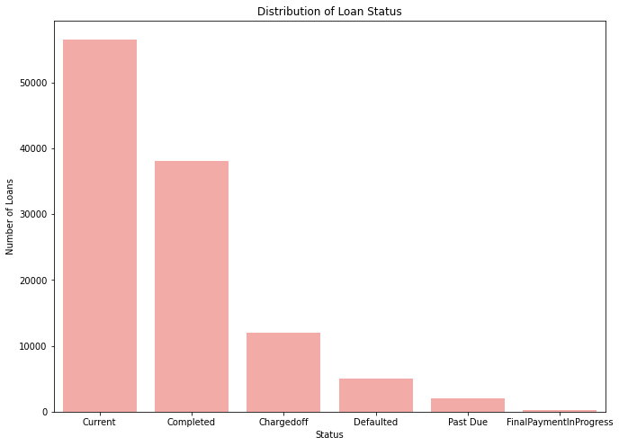

## Loan Status vs. Original Loan Amount

Current loans have a higher median original amount than the other statuses. This insight by itself should raise concerning among risk analysts. Hence, we should take into account any external factor or Prosper policy changes that justify this find, which is out of the scope of this project.

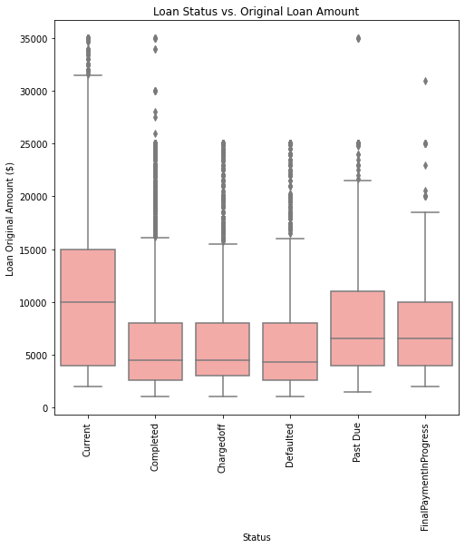

## Bivariate Exploration

To start off with, we will look at the pairwise correlations present between features in the data.

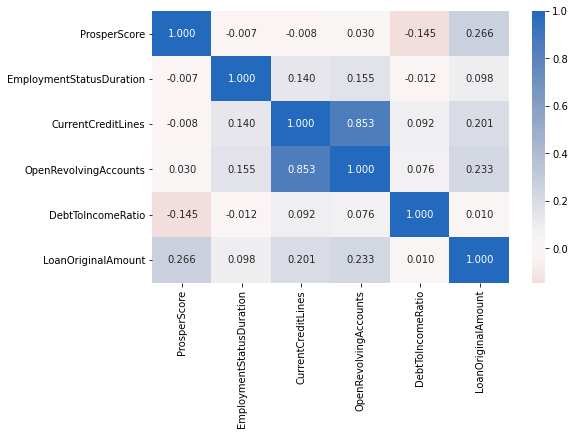